# R Assignment Notebook

```r
getwd()
```

```
[1] "C:/Users/Devin/Documents/GradSchool/IowaState/EEOB_546X/homework"
```

Inspecting snp_position.txt

```r
snp_position <- read.delim("snp_position.txt",header=TRUE, stringsAsFactors = FALSE)
dim(snp_position)
```

```
[1] 983  15
```

```r
colnames(snp_position[1:10])
```

```
 [1] "SNP_ID"               "cdv_marker_id"        "Chromosome"
 [4] "Position"             "alt_pos"              "mult_positions"
 [7] "amplicon"             "cdv_map_feature.name" "gene"
[10] "candidate.random"
```

```r
row.names(snp_position[1:10])
```

```
  [1] "1"   "2"   "3"   "4"   "5"   "6"   "7"   "8"   "9"   "10"  "11"
 [12] "12"  "13"  "14"  "15"  "16"  "17"  "18"  "19"  "20"  "21"  "22"
 [23] "23"  "24"  "25"  "26"  "27"  "28"  "29"  "30"  "31"  "32"  "33"
 [34] "34"  "35"  "36"  "37"  "38"  "39"  "40"  "41"  "42"  "43"  "44"
 [45] "45"  "46"  "47"  "48"  "49"  "50"  "51"  "52"  "53"  "54"  "55"
 [56] "56"  "57"  "58"  "59"  "60"  "61"  "62"  "63"  "64"  "65"  "66"
 [67] "67"  "68"  "69"  "70"  "71"  "72"  "73"  "74"  "75"  "76"  "77"
 [78] "78"  "79"  "80"  "81"  "82"  "83"  "84"  "85"  "86"  "87"  "88"
 [89] "89"  "90"  "91"  "92"  "93"  "94"  "95"  "96"  "97"  "98"  "99"
[100] "100" "101" "102" "103" "104" "105" "106" "107" "108" "109" "110"
[111] "111" "112" "113" "114" "115" "116" "117" "118" "119" "120" "121"
[122] "122" "123" "124" "125" "126" "127" "128" "129" "130" "131" "132"
[133] "133" "134" "135" "136" "137" "138" "139" "140" "141" "142" "143"
[144] "144" "145" "146" "147" "148" "149" "150" "151" "152" "153" "154"
[155] "155" "156" "157" "158" "159" "160" "161" "162" "163" "164" "165"
```

[output cut: 75 more lines]

Extract maize data from genotype_data.

```r
maize_genotype <- genotype_data[(genotype_data$Group == "ZMMIL") | (genotype_data$Group =="ZMMMR")| (genotype_data$Group == "ZMMLR"), ]
nrow(maize_genotype)
```

```
[1] 1573
```

```r
ncol(maize_genotype)
```

```
[1] 986
```

```r
unique(maize_genotype$Group)
```

```
[1] "ZMMLR" "ZMMMR" "ZMMIL"
```

Extract Teosinte data from genotype_data.

```r
teosinte_genotype <- genotype_data[(genotype_data$Group == "ZMPBA") | (genotype_data$Group =="ZMPIL")| (genotype_data$Group == "ZMPJA"), ]
nrow(teosinte_genotype)
```

```
[1] 975
```

```r
ncol(teosinte_genotype)
```

```
[1] 986
```

```r
unique(teosinte_genotype$Group)
```

```
[1] "ZMPBA" "ZMPJA" "ZMPIL"
```

Transposing teosinte and maize genotype data

```r
transposed_teosinte_genotype <- t(teosinte_genotype)
nrow(transposed_teosinte_genotype)
```

```
[1] 986
```

```r
ncol(transposed_teosinte_genotype)
```

```
[1] 975
```

```r
transposed_maize_genotype <- t(maize_genotype)
nrow(transposed_maize_genotype)
```

```
[1] 986
```

```r
ncol(transposed_maize_genotype)
```

```
[1] 1573
```

```r
#show the head of the first column for transposed_maize_genotype
head(transposed_maize_genotype[,1])
```

```
               Sample_ID                   JG_OTU                    Group
             "ZDP_0752a" "Zmm-LR-ACOM-usa-NM-1_s"                  "ZMMLR"
                abph1.20                 abph1.22                    ae1.3
                   "C/G"                    "A/A"                    "T/T"
```

```r
#remove the first three rows of tranposed_genotype as they are not important for merging
transposed_maize_genotype_without_header <- transposed_maize_genotype[-(1:3),]
#show the head of the new transposed_maize_genotype_without_header (without the first three rows of tranposed_maize_genotype)
head (transposed_maize_genotype_without_header[,1])
```

```
abph1.20 abph1.22    ae1.3    ae1.4    ae1.5    an1.4
   "C/G"    "A/A"    "T/T"    "G/G"    "C/C"    "C/G"
```

```r
head(transposed_teosinte_genotype[,1])
```

```
           Sample_ID               JG_OTU                Group
             "S0881" "Zmp-B-ACAPET-GR-01"              "ZMPBA"
            abph1.20             abph1.22                ae1.3
               "C/G"                "A/A"                "T/T"
```

```r
transposed_teosinte_genotype_without_header<-transposed_teosinte_genotype[-(1:3),]
head(transposed_teosinte_genotype_without_header[,1])
```

```
abph1.20 abph1.22    ae1.3    ae1.4    ae1.5    an1.4
   "C/G"    "A/A"    "T/T"    "G/G"    "T/T"    "C/C"
```

Merge tranposed_maize_genotype_without_header with snp_position.txt

```r
transposed_maize_genotype_without_header<-cbind(colnames(genotype_data[4:ncol(genotype_data)]),transposed_maize_genotype_without_header)
colnames(transposed_maize_genotype_without_header)[1]<-paste("SNP_ID")
maize_genotype_snp<-merge(snp_position,transposed_maize_genotype_without_header, by.x="SNP_ID", by.y="SNP_ID")
```

Remove unwanted columns from maize_genotype_snp. We only want the SNP_ID, the chromosome, the position and the genotype data.(Columns 1,3,4,16 to end)

```r
#colnames(maize_genotype_snp[1:20])
#colnames (maize_genotype_snp[c(1:20)])
#colnames(maize_genotype_snp[c(1,3,4,16:ncol(maize_genotype_snp))])
maize_genotype_snp<-maize_genotype_snp[c(1,3,4,16:ncol(maize_genotype_snp))]
#maize_genotype_snp[,-c(1:3)]<lapply(maize_genotype_snp[,-c(1:3)],as.character)
```

Merge transposed_teosinte_genotype_without_header with snp_position.txt

```r
transposed_teosinte_genotype_without_header<-cbind(colnames(genotype_data[4:ncol(genotype_data)]),transposed_teosinte_genotype_without_header)
colnames(transposed_teosinte_genotype_without_header)[1]<-paste("SNP_ID")
teosinte_genotype_snp<-merge(snp_position,transposed_teosinte_genotype_without_header, by.x="SNP_ID", by.y="SNP_ID")
```

Remove unwanted columns from teosinte_genotype_snp.

```r
teosinte_genotype_snp<-teosinte_genotype_snp[c(1,3,4,16:ncol(teosinte_genotype_snp))]
#sets columns 4:ncol(teosinte_genotype_snp) to character value
#teosinte_genotype_snp[,-c(1:3)]<-lapply(teosinte_genotype_snp[,-c(1:3)], as.character)
```

Seperate maize_genotype_snp into individual chromosome files.

```r
unique(maize_genotype_snp[,2])
```

```
 [1] "2"        "5"        "1"        "3"        "4"        "6"
 [7] "9"        "8"        "multiple" "7"        "unknown"  "10"
```

```r
for(i in 1:10){
      temp_chromosome_df<-maize_genotype_snp[maize_genotype_snp[,2]==i,]

      ordered_temp_chromosome_df<- temp_chromosome_df[order(as.numeric(temp_chromosome_df$Position)),]

      write.csv(ordered_temp_chromosome_df, sprintf("maize_chromosome_%d.csv",i), row.names=FALSE)
}
```

```
NAs introduced by coercionNAs introduced by coercionNAs introduced by coercionNAs introduced by coercionNAs introduced by coercion
```

```r
testing<-read.csv("maize_chromosome_1.csv")
```

Sort maize_chromosome_%d by position (descending) with ?/? substituted for -/-

```r
for(i in 1:10){
      temp_chromosome_df<-maize_genotype_snp[maize_genotype_snp[,2]==i,]
      temp_chromosome_df[,-c(1:3)]<-lapply(temp_chromosome_df[,-c(1:3)],as.character)

      #replace "?/?" with "-/-"
      temp_chromosome_df[temp_chromosome_df=="?/?"] <-"-/-"

      descending_order_temp_chromosome_df<- temp_chromosome_df[order(-(as.numeric(temp_chromosome_df$Position))),]

      write.csv(descending_order_temp_chromosome_df, sprintf("descending_order_maize_chromosome_%d.csv",i), row.names=FALSE)
}
```

```
NAs introduced by coercionNAs introduced by coercionNAs introduced by coercionNAs introduced by coercionNAs introduced by coercion
```

```r
descending_order_test<-read.csv("descending_order_maize_chromosome_1.csv")
```

Seperate teosinte_genotype_snp into individual chromosome files

```r
for(i in 1:10){
      temp_t_chromosome_df<-teosinte_genotype_snp[teosinte_genotype_snp[,2]==i,]

      ordered_temp_t_chromosome_df<- temp_t_chromosome_df[order(as.numeric(temp_t_chromosome_df$Position)),]

      write.csv(ordered_temp_t_chromosome_df, sprintf("teosinte_chromosome_%d.csv",i), row.names=FALSE)
      }
```

```
NAs introduced by coercionNAs introduced by coercionNAs introduced by coercionNAs introduced by coercionNAs introduced by coercion
```

Sort teosinte_chromosome%d by position (descending) with ?/? substituted for -/-

```r
for(i in 1:10){

      temp_teosinte_chromosome_df<-teosinte_genotype_snp[teosinte_genotype_snp[,2]==i,]
      temp_teosinte_chromosome_df[,-c(1:3)]<-lapply(temp_teosinte_chromosome_df[,-c(1:3)],as.character)
      #replace "?/?" with "-/-"
      temp_teosinte_chromosome_df[temp_teosinte_chromosome_df=="?/?"] <-"-/-"

      descending_order_temp_teosinte_chromosome_df<- temp_teosinte_chromosome_df[order(-(as.numeric(temp_teosinte_chromosome_df$Position))),]

      write.csv(descending_order_temp_teosinte_chromosome_df, sprintf("descending_order_teosinte_chromosome_%d.csv",i), row.names=FALSE)
}
```

```
NAs introduced by coercionNAs introduced by coercionNAs introduced by coercionNAs introduced by coercionNAs introduced by coercion
```

```r
descending_order_teosinte_test<-read.csv("descending_order_teosinte_chromosome_1.csv")
```

Import the reshape2, dplyr and ggplot2 packages.

```r
install.packages("reshape2")
install.packages("dplyr")
install.packages("ggplot2")
library(ggplot2)
library(dplyr)
library(reshape2)
```

Plot the total number of SNPs in out dataset on each chromosome.

```r
#typeof(genotype_data)
transposed_fang<-t(genotype_data)
#unique(genotype_data$Group)
transposed_fang<-as.data.frame(transposed_fang,row.names = FALSE)
groups<-transposed_fang[3,]
#typeof(groups)
transposed_fang<-transposed_fang[-(1:3),]
transposed_fang<-cbind(colnames(genotype_data[4:ncol(genotype_data)]),transposed_fang)#this adds the headers from the untransposed data back into a column form
colnames(transposed_fang)[1]<-paste("SNP_ID")
transposed_genotype_snp<-merge(snp_position,transposed_fang, by.x="SNP_ID", by.y="SNP_ID")
dim(transposed_genotype_snp)
```

```
[1]  983 2797
```

```r
dim(groups)
```

```
[1]    1 2782
```

```r
transposed_genotype_snp<-transposed_genotype_snp[c(1,3,4,16:ncol(transposed_genotype_snp))]
dim(transposed_genotype_snp)
```

```
[1]  983 2785
```

```r
groups<-cbind(0,0,0,groups)
colnames(groups)<-colnames(transposed_genotype_snp)
transposed_genotype_snp<-rbind(groups,transposed_genotype_snp)
groups_unique<-unique(genotype_data$Groups)
snp_chromosome_count_df<-data.frame()
for (i in 1:10){
  temp_chromosome_df<-transposed_genotype_snp[transposed_genotype_snp[,2]==i,]
  chromosome_count<-nrow(temp_chromosome_df)
  chromosome_count<-cbind(i,chromosome_count)
  snp_chromosome_count_df<-rbind(snp_chromosome_count_df, chromosome_count)
}
colnames(snp_chromosome_count_df)
```

```
[1] "i"                "chromosome_count"
```

```r
colnames(snp_chromosome_count_df)<-c("Chromosome","Number_of_SNPs")
  colnames(snp_chromosome_count_df)
```

```
[1] "Chromosome"     "Number_of_SNPs"
```

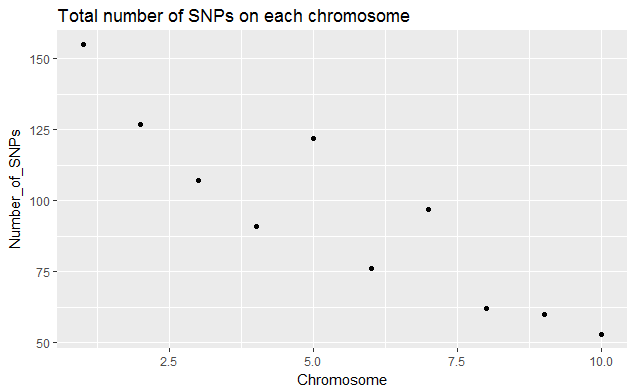

```r
ggplot(snp_chromosome_count_df) + geom_point(aes(x=Chromosome, y=Number_of_SNPs))+ ggtitle("Total number of SNPs on each chromosome")
```

How did groups contribute to the number of SNPs?

```r
 transposed_genotype_snp[,-c(1:3)]<-lapply(transposed_genotype_snp[,-c(1:3)],as.character)
SNPs_per_group<-data.frame()
groups_unique<-unique(genotype_data$Group)
for (i in 1:length(groups_unique)){
 temp_group_df<-transposed_genotype_snp[,transposed_genotype_snp[1,]== groups_unique[i]]

   #temp_group_df<-data.frame(transposed_genotype_snp[,transposed_genotype_snp[1,]== groups_unique[i]], stringsAsFactors = FALSE)
   #temp_group_df[,-c(1:3)]<-lapply(temp_group_df[,-c(1:3)],as.character)

  group_count<-ncol(temp_group_df)
  group_count<-cbind(groups_unique[i],group_count)
  SNPs_per_group<-rbind(SNPs_per_group, group_count)
}
colnames(SNPs_per_group)
```

```
[1] "V1"          "group_count"
```

```r
colnames(SNPs_per_group)<-c("Group", "Number_of_SNPs")
SNPs_per_group
```

|  | Group | Number_of_SNPs |
| --- | --- | --- |
| 1 | TRIPS | 22 |
| 2 | ZDIPL | 15 |
| 3 | ZPERR | 9 |
| 4 | ZLUXR | 17 |
| 5 | ZMHUE | 10 |
| 6 | ZMPBA | 900 |
| 7 | ZMPJA | 34 |
| 8 | ZMXCH | 75 |
| 9 | ZMXCP | 69 |
| 10 | ZMXNO | 7 |

[output cut: 6 more lines]

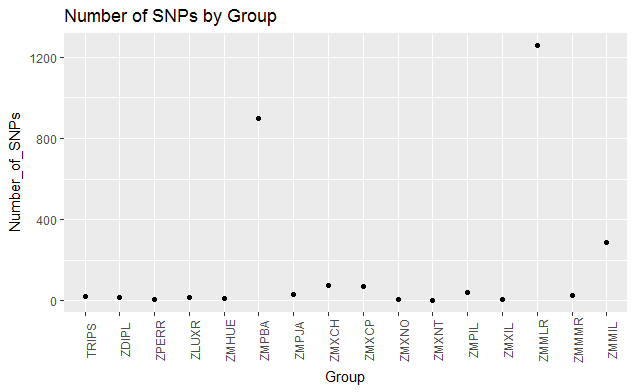

```r
SNPs_per_group$Number_of_SNPs<-as.numeric(levels(SNPs_per_group$Number_of_SNPs))[SNPs_per_group$Number_of_SNPs]
ggplot(SNPs_per_group, aes(x=Group, y=Number_of_SNPs))+geom_point()+theme(axis.text.x=element_text(angle=90)) +ggtitle("Number of SNPs by Group")
```

Missing Data and amount of heterozogosity and Sort by group and then by sample_ID

```r
genotype_data<-as.data.frame(genotype_data)
homozygous<-as.data.frame(matrix(ncol=1,nrow=nrow(genotype_data))) #adds homozygous column
total_NA<-as.data.frame(matrix(ncol=1,nrow=nrow(genotype_data)))
heterozygous<-as.data.frame(matrix(ncol=1,nrow=nrow(genotype_data)))
homozygous_df<-cbind(genotype_data[c(1:3)],homozygous,heterozygous,total_NA,genotype_data[c(4:ncol(genotype_data))])
colnames(homozygous_df)[4]<-paste("Homozygous_percent")
colnames(homozygous_df)[5]<-paste("Heterozygous_percent")
colnames(homozygous_df)[6]<-paste("NA_percent")
homozygous_df[homozygous_df=="?/?"] <- NA
for (i in 1:nrow(homozygous_df))
{
  SNPs<-homozygous_df[i,c(7:ncol(homozygous_df))]
  counter<-0

  for(j in 1:ncol(SNPs)){
    if (is.na(SNPs[1,j])==FALSE){
   if((SNPs[1,j] == "A/A") | (SNPs[1,j] == "T/T")| (SNPs[1,j] == "C/C") | (SNPs[1,j] == "G/G")){
     counter<-counter +1;
   }
   }
  }
  homozygous_df[i,6]<-sum(is.na(SNPs))/ncol(SNPs)
  homozygous_df[i,4]<-counter/ncol(SNPs)
  homozygous_df[i,5]<-1-(homozygous_df[i,4])-(homozygous_df[i,6])
}
homozygous_df_sorted<-homozygous_df[order(homozygous_df$Group),]
homozygous_df_sorted<-homozygous_df_sorted[order(homozygous_df_sorted$Sample_ID),]
```

Graph homozygousity, heterozygosity and NA_percentage

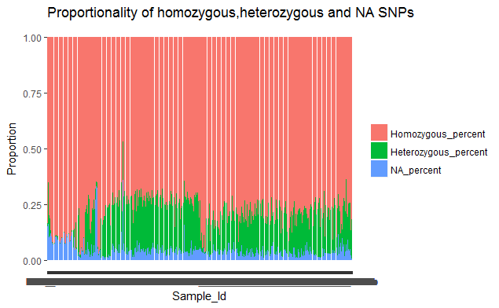

```r
temp_df<- melt(homozygous_df_sorted[c(1:6)], id= c("Sample_ID", "JG_OTU", "Group"))
ggplot(temp_df, aes(x=temp_df$Sample_ID, y=temp_df$value, fill=temp_df$variable))+geom_bar(stat="identity")+ xlab("Sample_Id") + ylab("Proportion")+ ggtitle("Proportionality of homozygous,heterozygous and NA SNPs")+ theme(legend.title=element_blank())
```

Homozygous/heterozygous/NA SNPs for maize

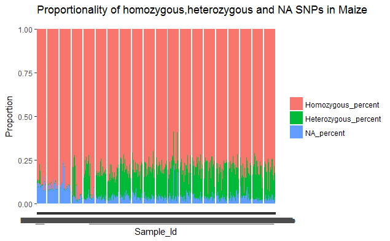

```r
maize_genotype<-as.data.frame(maize_genotype)
homozygous<-as.data.frame(matrix(ncol=1,nrow=nrow(maize_genotype))) #adds homozygous column
total_NA<-as.data.frame(matrix(ncol=1,nrow=nrow(maize_genotype)))
heterozygous<-as.data.frame(matrix(ncol=1,nrow=nrow(maize_genotype)))
homozygous_df<-cbind(maize_genotype[c(1:3)],homozygous,heterozygous,total_NA,maize_genotype[c(4:ncol(maize_genotype))])
colnames(homozygous_df)[4]<-paste("Homozygous_percent")
colnames(homozygous_df)[5]<-paste("Heterozygous_percent")
colnames(homozygous_df)[6]<-paste("NA_percent")
homozygous_df[homozygous_df=="?/?"] <- NA
for (i in 1:nrow(homozygous_df))
{
  SNPs<-homozygous_df[i,c(7:ncol(homozygous_df))]
  counter<-0

  for(j in 1:ncol(SNPs)){
    if (is.na(SNPs[1,j])==FALSE){
   if((SNPs[1,j] == "A/A") | (SNPs[1,j] == "T/T")| (SNPs[1,j] == "C/C") | (SNPs[1,j] == "G/G")){
     counter<-counter +1;
   }
   }
  }
  homozygous_df[i,6]<-sum(is.na(SNPs))/ncol(SNPs)
  homozygous_df[i,4]<-counter/ncol(SNPs)
  homozygous_df[i,5]<-1-(homozygous_df[i,4])-(homozygous_df[i,6])
}
homozygous_df_sorted<-homozygous_df[order(homozygous_df$Group),]
homozygous_df_sorted<-homozygous_df_sorted[order(homozygous_df_sorted$Sample_ID),]
temp_df<- melt(homozygous_df_sorted[c(1:6)], id= c("Sample_ID", "JG_OTU", "Group"))
ggplot(temp_df, aes(x=temp_df$Sample_ID, y=temp_df$value, fill=temp_df$variable))+geom_bar(stat="identity")+ xlab("Sample_Id") + ylab("Proportion")+ ggtitle("Proportionality of homozygous,heterozygous and NA SNPs in Maize")+ theme(legend.title=element_blank())
```

Homozygous/Heterozygous/NA SNPs in teosinte

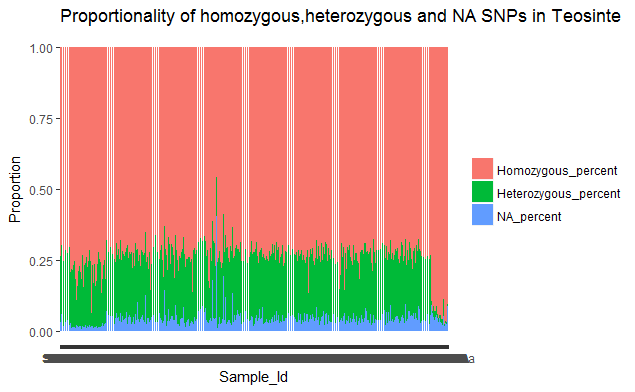

```r
teosinte_genotype<-as.data.frame(teosinte_genotype)
homozygous<-as.data.frame(matrix(ncol=1,nrow=nrow(teosinte_genotype))) #adds homozygous column
total_NA<-as.data.frame(matrix(ncol=1,nrow=nrow(teosinte_genotype)))
heterozygous<-as.data.frame(matrix(ncol=1,nrow=nrow(teosinte_genotype)))
homozygous_df<-cbind(teosinte_genotype[c(1:3)],homozygous,heterozygous,total_NA,teosinte_genotype[c(4:ncol(teosinte_genotype))])
colnames(homozygous_df)[4]<-paste("Homozygous_percent")
colnames(homozygous_df)[5]<-paste("Heterozygous_percent")
colnames(homozygous_df)[6]<-paste("NA_percent")
homozygous_df[homozygous_df=="?/?"] <- NA
for (i in 1:nrow(homozygous_df))
{
  SNPs<-homozygous_df[i,c(7:ncol(homozygous_df))]
  counter<-0

  for(j in 1:ncol(SNPs)){
    if (is.na(SNPs[1,j])==FALSE){
   if((SNPs[1,j] == "A/A") | (SNPs[1,j] == "T/T")| (SNPs[1,j] == "C/C") | (SNPs[1,j] == "G/G")){
     counter<-counter +1;
   }
   }
  }
  homozygous_df[i,6]<-sum(is.na(SNPs))/ncol(SNPs)
  homozygous_df[i,4]<-counter/ncol(SNPs)
  homozygous_df[i,5]<-1-(homozygous_df[i,4])-(homozygous_df[i,6])
}
homozygous_df_sorted<-homozygous_df[order(homozygous_df$Group),]
homozygous_df_sorted<-homozygous_df_sorted[order(homozygous_df_sorted$Sample_ID),]
temp_df<- melt(homozygous_df_sorted[c(1:6)], id= c("Sample_ID", "JG_OTU", "Group"))
ggplot(temp_df, aes(x=temp_df$Sample_ID, y=temp_df$value, fill=temp_df$variable))+geom_bar(stat="identity")+ xlab("Sample_Id") + ylab("Proportion")+ ggtitle("Proportionality of homozygous,heterozygous and NA SNPs in Teosinte")+ theme(legend.title=element_blank())
```